# Assignment-3

Mandhri Abeysooriya and Rusheni Senanayake

# PART-1.

## Question1-(Read in the file, making the gene accession numbers the row names. Show a table of values for the first six genes).

In order to address this question, initially download the given file “gene_expression.tsv” whichcontains RNA-seq count data for two samples of interest. Use the command, download.file (“URL”,destfile=“name”) to download “gene expression.tsv”.destfile=“name” command will be used to give the destination name for the downloaded file. secondly,read the file using command, read.table(“name of the file”) Then to make an object, the data set needed to be saved under a name in environment. In here the name of the object will be given as “x” In oder to save the file as an object, run x<-read.table(“geneexpression.tsv”, header = TRUE) command. Then look the first six genes using head(x) Full code use to solve the problem is,

```r
download.file("https://raw.githubusercontent.com/markziemann/SLE712_files/master/bioinfo_asst3_part1_files/gene_expression.tsv",destfile = "geneexpression.tsv")

x<-read.table("geneexpression.tsv", header = TRUE)
head(x)
```

```
##            GeneID SRR5150592 SRR5150593
## 1 ENSG00000223972          1          0
## 2 ENSG00000227232          0          1
## 3 ENSG00000278267          0          0
## 4 ENSG00000243485          0          0
## 5 ENSG00000284332          0          0
## 6 ENSG00000237613          0          0
```

## Question2-(Make a new column which is the mean of the other columns. Show a table of values for the first sixgenes.)

An object named “meanofsamples” is saved in the environment using meanofthesample <- and then to find the means of each row, rowmeans() function is used. The reason for the use of rowMeans is that this fucntion will produce the mean in considering the every row where as columns are being selective. rowmeans(x[,c(2:3)]) command will give an output where mean of the rows will be calculated by considering columns 2 and 3. Comma used as soon as square brackets open depicts the fact that this function consider all the rows. Therfore full code can be written as x$meanofsamples<-rowMeans(x[,c(2:3)]) and to check the means for first six genes run x[1:6,] Spefic columns on the table will be selected by using the syntax($) to run the command.

Code to use in solving problem is,

```r
meanofsamples<-rowMeans(x[,c(2:3)])
x$meanofsamples<-rowMeans(x[,c(2:3)])
x[1:6,]
```

```
##            GeneID SRR5150592 SRR5150593 meanofsamples
## 1 ENSG00000223972          1          0           0.5
## 2 ENSG00000227232          0          1           0.5
## 3 ENSG00000278267          0          0           0.0
## 4 ENSG00000243485          0          0           0.0
## 5 ENSG00000284332          0          0           0.0
## 6 ENSG00000237613          0          0           0.0
```

## Question 3-(List the 10 genes with the highest mean expression)

Values in the column (meanofsamples) will be arranged in descending order and named as “ranks”. decreasing argument will be TRUE. This will be giving the results of the highest values to the lowest values of the column(meanofsamples) in reference to “GeneID” Order() will results with ranking positions for each element. Sort() will be sorting out the results in reference to “meanofsample” column. decreasing will be true to obtain highest value in numeric. Since the object “ranks” composed of interger data type, as,data frame(x[ranks,]) will be used to convert the integer data type to a data frame. An object named “decended” will be created and first 10 rows of all the columns will be executed with the command, decended[1:10,] This will be providing the highest mean values of the samples.

Following table show the first ten genes with highest genes.

```r
ranks <-order(x$meanofsamples,decreasing = T)
ranks
```

```
##     [1]  8683 58210 20619 58234 42896 58222 58238 25675 58225 49030 49883 58241
##    [13] 56907 32090 31896 19209 58228 58229 19897 43183 17109 52796 22286 20902
##    [25] 33376   294 58212 43695 43431 41993  8990 33563  2098 35995 41989 10914
##    [37]  9212 47019 26693 18351 30879 58216  6108  6136 30038 58239 34156 27472
##    [49] 47031  6592 18879  4373 53284 10271 28370 43100 28059  4008 28662 35736
##    [61] 57690 48493 44728 49393  8277 34714 43584 41268 44224 38047  5117 53437
##    [73] 52379 19060 38385 37248 48890  1327 24329 23534 47316 57042 39314 29941
##    [85] 17565 31015 58208  9003 10048 22085 22819 36771 37145 48626 37651 32493
##    [97] 17559 11967 36023 29241  9213 20214 40008 49229  1409 43479  9970 28123
##   [109]   136 17347   781 17629 38572  5839  1226 12550 40010  2624 24217   748
##   [121] 18566 47188 54206 37140 31216  8698 22697 16749 38129 37279 11959  6024
##   [133] 41019  4061 33906 49904 45507 14709  4558  5998 21109 53129  3237 22435
##   [145] 57002 37539 35588 18681 23878  2215  4984 31398 30174 58233 56959  3031
##   [157] 54801  1117 34870 30210 22514   817 11391 48290  6903  6202  6289  8376
##   [169] 57859 15530 57113 10799  9802 45620 36920 47023  1887 22701  3795 15763
```

[output cut: 4844 more lines]

```r
sort(x$meanofsamples,decreasing = T,)
```

```
##     [1] 259102.0 154602.0 125372.5  95769.5  84852.0  82303.0  79079.5  77319.0
##     [9]  76608.0  70234.5  67619.0  65966.5  63670.0  57972.0  56678.0  55528.0
##    [17]  48137.5  44411.5  42762.5  40345.0  39988.5  39669.5  39568.0  39354.5
##    [25]  39305.0  37430.5  36985.0  36369.0  35500.5  35466.0  35017.5  34180.0
##    [33]  33653.0  32819.0  31806.0  31402.5  31245.5  30849.0  30695.0  30035.0
##    [41]  29875.5  29702.5  26877.5  26461.0  26413.5  25944.5  25285.0  24967.5
##    [49]  24916.0  24448.0  24328.0  24127.0  24069.0  23230.5  23201.0  22739.5
##    [57]  22446.5  22048.0  21825.0  21650.0  21573.0  21208.5  21168.5  21043.5
##    [65]  20784.5  20608.5  20454.5  20361.5  20345.0  20337.5  20333.0  20248.5
##    [73]  20181.0  20138.0  19667.0  19501.5  19437.5  19304.0  19184.0  19148.5
##    [81]  18926.0  18815.0  18755.0  18593.0  18454.5  18431.5  18426.5  18240.5
##    [89]  18230.0  18155.0  17949.0  17718.0  17620.0  17568.0  17411.0  17358.0
##    [97]  17268.0  17129.0  17007.0  16980.5  16910.5  16718.0  16674.0  16597.0
##   [105]  16587.5  16575.0  16517.0  16504.5  16479.5  16461.5  16220.5  16138.0
##   [113]  16064.0  16051.0  15912.5  15783.0  15694.5  15683.5  15634.0  15615.0
```

[output cut: 7273 more lines]

```r
decended <-as.data.frame(x[ranks,])
decended[1:10,]
```

```
##                GeneID SRR5150592 SRR5150593 meanofsamples
## 8683  ENSG00000115414     311857     206347      259102.0
## 58210 ENSG00000210082     145916     163288      154602.0
## 20619 ENSG00000075624     133983     116762      125372.5
## 58234 ENSG00000198886      91596      99943       95769.5
## 42896 ENSG00000137801      95158      74546       84852.0
## 58222 ENSG00000198804      79832      84774       82303.0
## 58238 ENSG00000198786      74570      83589       79079.5
## 25675 ENSG00000196924      88225      66413       77319.0
## 58225 ENSG00000198712      76108      77108       76608.0
## 49030 ENSG00000108821      80342      60127       70234.5
```

## Question 4-(Determine the number of genes with a mean <10)

Codes use to solving problem is,

```r
filtered <- subset(x, meanofsamples > 10)
nrow(filtered)
```

```
## [1] 15032
```

## Question 5 -(Make a histogram plot of the mean values in png format and paste it into your report.

Histogram were drawn using hist() function and for easy identification break it to 5 frequencies.histogram were drawn in mean of th samples in the x axis and frequancy was taken to y axis.To save the image in png format export the drawn graph and save the option under png format.

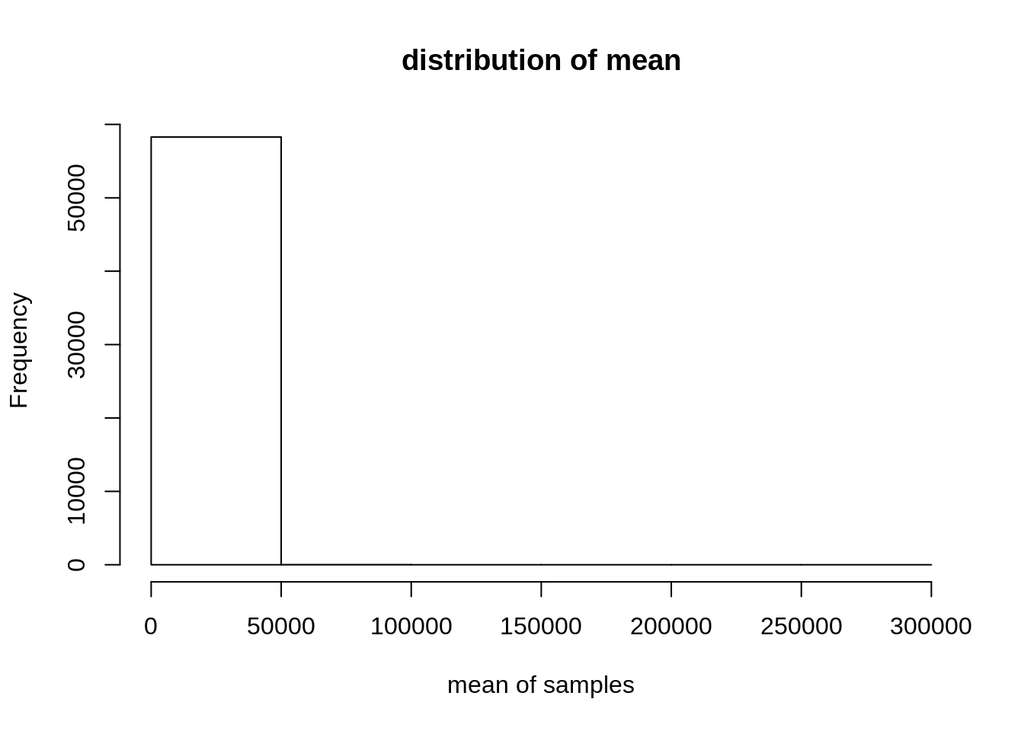

```r
hist(x$meanofsample,main="distribution of mean",xlab="mean of samples",breaks=5)
```

## Question 6 -(Import this csv file into an R object. What are the column names?)

Initially run args() to find the arguments needed to read a csv file. Then,In order to make an object, the data set needed to be saved under a name in environment. So for that, the name of the object will be given as “R”. In oder to save the file as an object, run the command. R<-read.csv(file=“tree_circumference,csv”,header=true,sep=“,”). Then run the command to depict the table in console by typing R . To know the names of the columns in the cvs file, run the command, colnames(R).This step will provide with column names as characters.

```r
args(read.csv)
```

```
## function (file, header = TRUE, sep = ",", quote = "\"", dec = ".",
##     fill = TRUE, comment.char = "", ...)
## NULL
```

```r
R<-read.csv(file = "https://raw.githubusercontent.com/markziemann/SLE712_files/master/bioinfo_asst3_part1_files/growth_data.csv",header = TRUE,sep = ",")
R
```

```
##          Site TreeID Circumf_2004_cm Circumf_2009_cm Circumf_2014_cm
## 1   northeast   A003             5.2            10.1            19.9
## 2   northeast   A005             4.9             9.6            18.9
## 3   northeast   A007             3.7             7.3            14.3
## 4   northeast   A008             3.8             6.5            10.9
## 5   northeast   A011             3.8             6.4            10.9
## 6   northeast   A012             5.9            10.0            16.8
## 7   northeast   A016             4.4             9.9            22.2
## 8   northeast   A019             5.3             9.0            15.2
## 9   northeast   A022             7.1            12.0            20.2
## 10  northeast   A025             3.8             7.4            14.5
## 11  northeast   A026             5.4            10.5            20.6
## 12  northeast   A030             3.5             6.8            13.3
## 13  northeast   A034             2.4             4.1             7.0
## 14  northeast   A035             5.9            13.3            30.0
```

[output cut: 187 more lines]

```r
colnames(R)
```

```
## [1] "Site"            "TreeID"          "Circumf_2004_cm" "Circumf_2009_cm"
## [5] "Circumf_2014_cm" "Circumf_2019_cm"
```

## Question 7-(Calculate the mean and standard deviation of tree circumference at the start and end of the study at both sites)

To calculate the mean and sd of the both sites, mean() and sd() are used. It shuould be noted that the column needed to be specified from the Table(R). Then Make a subset for two sites(northeast and southwest). Name the subset as “Northeast” and “Southwest”. In Northeast <-(R[R$Site==“northeast”,]) - the name of the subset is Northeast. R is the table which include the data of cvs file. Define the column of Interest in the table using the symbol($). ""syntax defines R$Site eqivalent to “northeast”. In Northeast <-(R[R$Site==“northeast”,]) a comma after “northeast” suggest that the function is run in all columns.

mean and SD values of sites are,

```r
#Northeast
Northeast <-(R[R$Site=="northeast",])
Northeast
```

```
##         Site TreeID Circumf_2004_cm Circumf_2009_cm Circumf_2014_cm
## 1  northeast   A003             5.2            10.1            19.9
## 2  northeast   A005             4.9             9.6            18.9
## 3  northeast   A007             3.7             7.3            14.3
## 4  northeast   A008             3.8             6.5            10.9
## 5  northeast   A011             3.8             6.4            10.9
## 6  northeast   A012             5.9            10.0            16.8
## 7  northeast   A016             4.4             9.9            22.2
## 8  northeast   A019             5.3             9.0            15.2
## 9  northeast   A022             7.1            12.0            20.2
## 10 northeast   A025             3.8             7.4            14.5
## 11 northeast   A026             5.4            10.5            20.6
## 12 northeast   A030             3.5             6.8            13.3
## 13 northeast   A034             2.4             4.1             7.0
## 14 northeast   A035             5.9            13.3            30.0
```

[output cut: 87 more lines]

```r
mean(Northeast$Circumf_2004_cm)
```

```
## [1] 5.078
```

```r
sd(Northeast$Circumf_2004_cm)
```

```
## [1] 1.059127
```

```r
mean(Northeast$Circumf_2019_cm)
```

```
## [1] 40.052
```

```r
sd(Northeast$Circumf_2019_cm)
```

```
## [1] 16.90443
```

```r
#Southwest
Southwest <-(R[R$Site=="southwest",])
Southwest
```

```
##          Site TreeID Circumf_2004_cm Circumf_2009_cm Circumf_2014_cm
## 51  southwest   A001             5.3            13.5            34.6
## 52  southwest   A002             5.2            10.1            19.8
## 53  southwest   A004             6.2            15.9            40.6
## 54  southwest   A006             5.1            11.5            25.9
## 55  southwest   A009             3.6             9.1            23.4
## 56  southwest   A010             6.6            14.9            33.6
## 57  southwest   A013             6.6            16.9            43.2
## 58  southwest   A014             5.1            12.9            33.2
## 59  southwest   A015             4.1            10.6            27.1
## 60  southwest   A017             4.4             8.7            17.0
## 61  southwest   A018             3.9             8.9            19.9
## 62  southwest   A020             5.4            10.6            20.7
## 63  southwest   A021             4.7            12.1            31.0
## 64  southwest   A023             4.2             9.4            21.1
```

[output cut: 87 more lines]

```r
mean(Southwest$Circumf_2004_cm)
```

```
## [1] 5.076
```

```r
sd(Southwest$Circumf_2004_cm)
```

```
## [1] 1.060527
```

```r
mean(Southwest$Circumf_2019_cm)
```

```
## [1] 59.772
```

```r
sd(Southwest$Circumf_2019_cm)
```

```
## [1] 22.57784
```

## Question 8-(Make a box plot of tree circumference at the start and end of the study at both sites)

Box plots were drawn for both the sites using the function boxplot() to obtain the box plot for specific column. Since it is for both the sites, it is better to run the function by selecting Northeast and Southwest objects instead R.

Box plots for northeast,

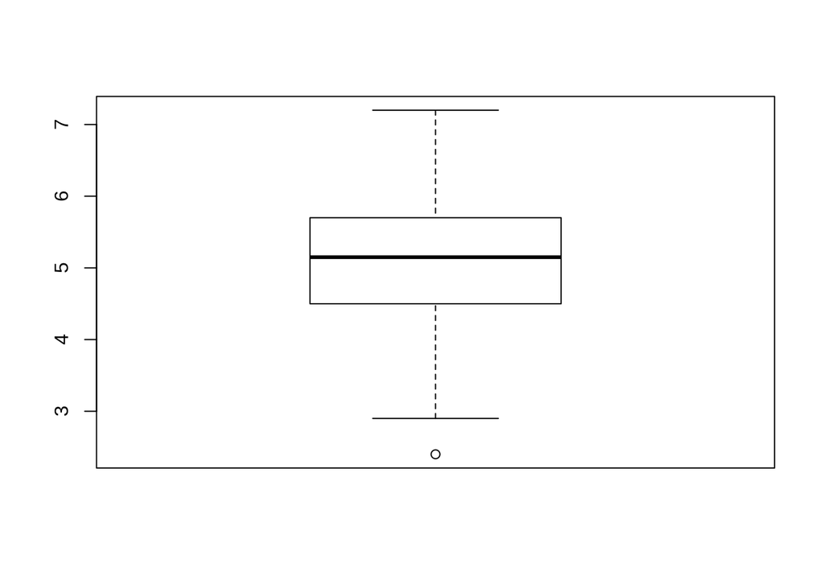

```r
boxplot(Northeast$Circumf_2004_cm)
```

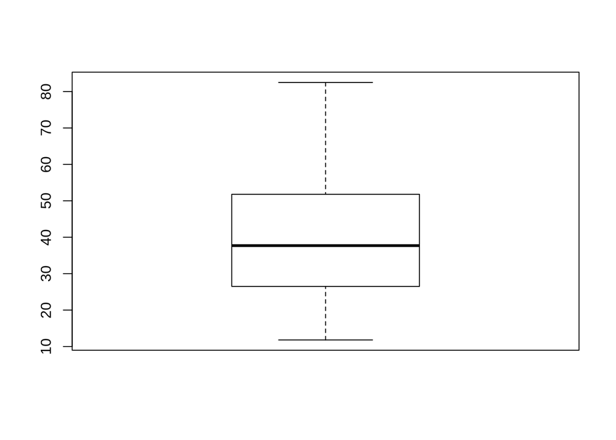

```r
boxplot(Northeast$Circumf_2019_cm)
```

Boxplotsfor southwest,

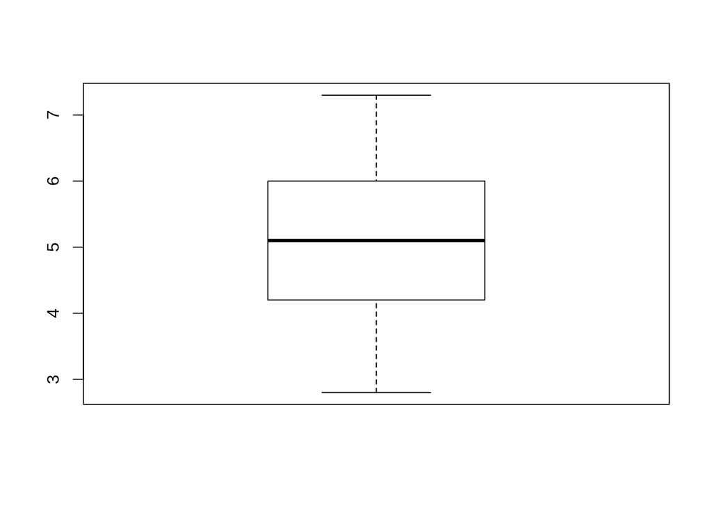

```r
boxplot(Southwest$Circumf_2004_cm)
```

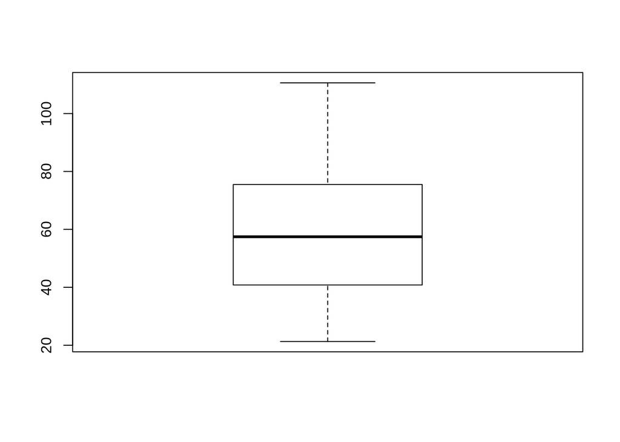

```r
boxplot(Southwest$Circumf_2019_cm)
```

### Making a one box plot

Combining all the 4 box plots to a single box plot diagram. Use function xlab() to give the title for x-axis, ylab() for title to y-axis,main() is for title of the plot,Names() function is used to give names to each sectors. boxplot(main=“circumferences of trees in two sites”,Northeast$Circumf_2004_cm,Northeast$Circumf_2019_cm,Southwest$Circumf_2004_cm,Southwest$Circumf_2019_cm,names=c(“N2004”,“N2019”,“S2004”,“S2019”),ylab=“Circumference(cm)”,xlab=“Trees”)

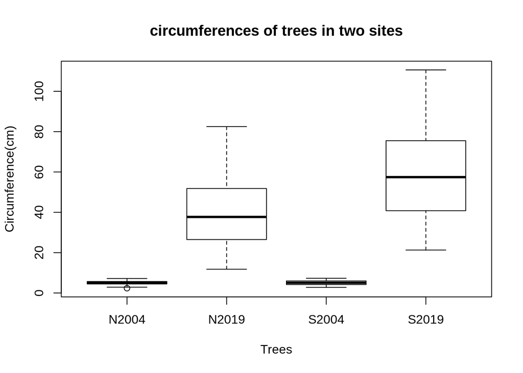

```r
boxplot(main="circumferences of trees in two sites",Northeast$Circumf_2004_cm,Northeast$Circumf_2019_cm,Southwest$Circumf_2004_cm,Southwest$Circumf_2019_cm,names=c("N2004","N2019","S2004","S2019"),ylab="Circumference(cm)",xlab="Trees")
```

## Question 9-(Calculate the mean growth over the past 10 years at each site.)

### Creating the mean growth of the two subsets(Northeast and Southwest)

```r
args(rowMeans)
```

```
## function (x, na.rm = FALSE, dims = 1L)
## NULL
```

```r
growth_Northeast <- rowMeans(Northeast[,c(4:6)])
growth_Northeast
```

```
##         1         2         3         4         5         6         7         8
## 22.966667 21.833333 16.566667 11.966667 11.900000 18.400000 27.366667 16.666667
##         9        10        11        12        13        14        15        16
## 22.133333 16.766667 23.866667 15.366667  7.633333 36.966667 20.333333 12.866667
##        17        18        19        20        21        22        23        24
## 15.666667 45.166667 30.933333 28.966667 33.833333 41.466667 29.333333 19.733333
##        25        26        27        28        29        30        31        32
## 22.666667 29.866667 22.800000 31.766667 32.766667 33.766667 18.133333 26.833333
##        33        34        35        36        37        38        39        40
## 28.333333 27.566667 15.600000 24.500000 14.966667 14.300000 21.266667 25.466667
##        41        42        43        44        45        46        47        48
## 20.933333 16.500000 17.166667 17.600000 24.100000 17.733333 33.500000 42.800000
##        49        50
## 12.333333 22.766667
```

```r
growth_Southwest <- rowMeans(Southwest[,c(4:6)])
growth_Southwest
```

```
##       51       52       53       54       55       56       57       58
## 45.60000 22.90000 53.46667 31.90000 30.76667 41.33333 56.90000 43.66667
##       59       60       61       62       63       64       65       66
## 35.66667 19.66667 24.53333 23.96667 40.80000 26.03333 17.23333 43.30000
##       67       68       69       70       71       72       73       74
## 33.36667 37.96667 16.80000 32.40000 31.60000 33.26667 39.73333 12.56667
##       75       76       77       78       79       80       81       82
## 51.73333 25.73333 40.16667 22.90000 47.53333 29.30000 18.76667 21.06667
##       83       84       85       86       87       88       89       90
## 24.06667 34.06667 20.46667 27.26667 40.13333 43.10000 26.73333 48.66667
##       91       92       93       94       95       96       97       98
## 35.36667 27.63333 19.90000 28.33333 52.50000 22.43333 31.30000 31.13333
##       99      100
## 20.16667 33.53333
```

### Insert the new column to both the tables created under North_east and South_west

Run args() funtion to find the arguments needed for the rowMeans. Northeast$Circumf_2004 The reason for the use of rowMeans is that this fucntion will produce the mean in considering the every row where as selective columns are being sellected. column 4 and column 6 are specified as they hold data for a 10 years time period.

```r
Northeast$growth_Northeast <-rowMeans(Northeast[,c(4:6)])
Northeast
```

```
##         Site TreeID Circumf_2004_cm Circumf_2009_cm Circumf_2014_cm
## 1  northeast   A003             5.2            10.1            19.9
## 2  northeast   A005             4.9             9.6            18.9
## 3  northeast   A007             3.7             7.3            14.3
## 4  northeast   A008             3.8             6.5            10.9
## 5  northeast   A011             3.8             6.4            10.9
## 6  northeast   A012             5.9            10.0            16.8
## 7  northeast   A016             4.4             9.9            22.2
## 8  northeast   A019             5.3             9.0            15.2
## 9  northeast   A022             7.1            12.0            20.2
## 10 northeast   A025             3.8             7.4            14.5
## 11 northeast   A026             5.4            10.5            20.6
## 12 northeast   A030             3.5             6.8            13.3
## 13 northeast   A034             2.4             4.1             7.0
## 14 northeast   A035             5.9            13.3            30.0
```

[output cut: 87 more lines]

```r
Southwest$growth_Southwest <-rowMeans(Southwest[,c(4:6)])
Southwest
```

```
##          Site TreeID Circumf_2004_cm Circumf_2009_cm Circumf_2014_cm
## 51  southwest   A001             5.3            13.5            34.6
## 52  southwest   A002             5.2            10.1            19.8
## 53  southwest   A004             6.2            15.9            40.6
## 54  southwest   A006             5.1            11.5            25.9
## 55  southwest   A009             3.6             9.1            23.4
## 56  southwest   A010             6.6            14.9            33.6
## 57  southwest   A013             6.6            16.9            43.2
## 58  southwest   A014             5.1            12.9            33.2
## 59  southwest   A015             4.1            10.6            27.1
## 60  southwest   A017             4.4             8.7            17.0
## 61  southwest   A018             3.9             8.9            19.9
## 62  southwest   A020             5.4            10.6            20.7
## 63  southwest   A021             4.7            12.1            31.0
## 64  southwest   A023             4.2             9.4            21.1
```

[output cut: 87 more lines]

## Question 10-(Use the t.test and wilcox.test functions to estimate the p-value that the 10 year growth is different at the two sites.)

Select the data frames which compose of mean of growth of two sites:growth_Northeast and growth_Southwest

### Application of t-test

The syntax used below is for a two sample t-test. The reason for use of two sample t-test is that samples of interest are collected from two sides.

```r
t.test(growth_Northeast,growth_Southwest)
```

```
##
##  Welch Two Sample t-test
##
## data:  growth_Northeast and growth_Southwest
## t = -4.6819, df = 92.914, p-value = 9.662e-06
## alternative hypothesis: true difference in means is not equal to 0
## 95 percent confidence interval:
##  -12.951192  -5.236808
## sample estimates:
## mean of x mean of y
##  23.29467  32.38867
```

### Analysing t-test data

According to the p value which is 9.662e-06, it can be assume that the there is strong evidence aginst nulll hypothesis stating the fact that null hypothesis can be rejected. The mean of northeast is 23.29467 where as mena of southwest is 32.38867. Accoridngly, the mean of southwest is greater than northeast

### Application of Wilcox test

```r
args(wilcox.test)
```

```
## function (x, ...)
## NULL
```

```r
wilcox.test(growth_Northeast,growth_Southwest)
```

```
##
##  Wilcoxon rank sum test with continuity correction
##
## data:  growth_Northeast and growth_Southwest
## W = 635.5, p-value = 2.308e-05
## alternative hypothesis: true location shift is not equal to 0
```

### Analysing wilcox data

```r
wilcox.test(growth_Northeast,growth_Southwest)
```

```
##
##  Wilcoxon rank sum test with continuity correction
##
## data:  growth_Northeast and growth_Southwest
## W = 635.5, p-value = 2.308e-05
## alternative hypothesis: true location shift is not equal to 0
```

A larer p value is obtained compared to t-test. Its assumed to be accurate as Wilcox.test relies onn different statstics. Since Wilcox test is non parametric, the results tend to be less sensitive with more robust.

# Part 2

```r
library("seqinr")
library("R.utils")
library("rBLAST")
library("ape")
library("ORFik")
library("Biostrings")
```

## Question 1-(Download the whole set of E. coli gene DNA sequences and use gunzip to decompress. Use the makeblast() function to create a blast database. How many sequences are present in the E.coli set?)

### Download the whole set of E. coli gene DNA sequences and use gunzip to decompress

Download the whole set of E. coli gene DNA sequences and use gunzip to decompress) The link with fa.gv is selected as in the 1st question, it is mentioned to decompress and fa.gv extensioned file are compressed files. So the link was selected and fa.gz extension was given to destile name.

```r
download.file('ftp://ftp.ensemblgenomes.org/pub/bacteria/release-42/fasta/bacteria_0_collection/escherichia_coli_str_k_12_substr_mg1655/cds/Escherichia_coli_str_k_12_substr_mg1655.ASM584v2.cds.all.fa.gz',
              destfile = "ecoligene.fa.gz")
```

### uncompress the file

R.utils package was used whereas gunzip command assit in unzipping the document. The name of the file was given with the extension. overwrite command was selected as True to keep the original file in the system.

```r
R.utils::gunzip("ecoligene.fa.gz",overwrite=T)
```

### Making blast data base

```r
makeblastdb("ecoligene.fa",dbtype = "nucl","-parse_seqids")
```

## Question 2-(Download the sample fasta sequences and read them in as above. For your allocated sequence, determine the length (in bp) and the proportion of GC bases).

### Download the sample fasta sequences and read them in as above. For the allocated sequence and determine the length (in bp) and the proportion of GC bases.

Download the sample fasta sequences and read them in as above. For your allocated sequence, Determine the length (in bp) and the proportion of GC bases. Downloading the file given in assigment pdf file which is of extension fa. Since the file is of extension fa,it is clear that the file is already uncompressseed

```r
download.file("https://raw.githubusercontent.com/markziemann/SLE712_files/master/bioinfo_asst3_part2_files/sample.fa",
              destfile = "sample.fa")
```

### read.fasta command is given to read the downloaded fasta sequences.

Downloaded fastas are saved in working directory as “samplefastas”

```r
samplefastas <- read.fasta("sample.fa")
```

### one fasta sequence is been selected from the downloaded fasta sequence.

9th sequence is been selected and saved in the working directory as “Groupseq”

```r
Groupseq <-samplefastas [[9]]
Groupseq
```

```
##   [1] "a" "t" "g" "a" "t" "g" "t" "t" "c" "t" "g" "g" "c" "g" "c" "a" "t" "t"
##  [19] "t" "t" "c" "c" "g" "t" "c" "t" "t" "g" "a" "g" "c" "t" "g" "c" "g" "t"
##  [37] "g" "t" "a" "g" "c" "g" "t" "t" "t" "c" "g" "c" "c" "a" "t" "a" "g" "c"
##  [55] "g" "c" "c" "g" "a" "a" "a" "t" "c" "g" "c" "c" "a" "a" "c" "c" "c" "g"
##  [73] "c" "t" "g" "t" "g" "g" "t" "t" "c" "t" "t" "c" "c" "t" "g" "a" "t" "t"
##  [91] "g" "t" "a" "a" "t" "t" "a" "c" "c" "c" "t" "t" "t" "t" "t" "c" "c" "g"
## [109] "c" "t" "c" "a" "g" "t" "a" "t" "c" "g" "g" "t" "c" "c" "g" "g" "a" "g"
## [127] "c" "c" "g" "c" "a" "a" "c" "t" "g" "c" "t" "g" "g" "c" "g" "c" "g" "t"
## [145] "a" "t" "t" "g" "c" "a" "c" "c" "g" "g" "g" "c" "a" "t" "t" "a" "t" "c"
## [163] "t" "g" "g" "g" "t" "t" "g" "c" "t" "g" "c" "g" "c" "t" "g" "c" "t" "t"
## [181] "t" "c" "a" "t" "c" "c" "t" "t" "g" "c" "t" "g" "g" "c" "g" "c" "t" "g"
## [199] "g" "a" "a" "c" "g" "a" "c" "t" "g" "t" "t" "c" "c" "g" "t" "g" "a" "c"
## [217] "g" "a" "t" "t" "t" "g" "c" "a" "g" "g" "a" "c" "g" "g" "c" "a" "g" "t"
## [235] "c" "t" "t" "g" "a" "a" "c" "a" "a" "t" "t" "g" "a" "t" "g" "t" "t" "g"
## [253] "t" "t" "g" "c" "c" "g" "t" "t" "a" "c" "c" "c" "t" "t" "g" "c" "c" "c"
```

[output cut: 28 more lines]

#length of 9th fasta seq

```r
seqinr::getLength(Groupseq)
```

```
## [1] 663
```

#length of GC propotion

```r
seqinr::GC(Groupseq)
```

```
## [1] 0.5595777
```

## Question 3-(You will be provided with R functions to create BLAST databases and perform blast searches. Use blast to identify what E. coli gene your sequence matches best. Show a table of the top 3 hits including percent identity, E-value and bit scores.You will be provided with R functions to create BLAST databases and perform blast searches. Use blast to identify what E. coli gene your sequence matches best. Show a table of the top 3 hits including percent identity, E-value and bit scores).

### making the necessary functions avaialble in environment

Make the sequences of commands avaialble in environment, which would allow the user to run blast

```r
source("https://raw.githubusercontent.com/markziemann/SLE712_files/master/bioinfo_asst3_part2_files/mutblast_functions.R")
download.file("https://raw.githubusercontent.com/markziemann/SLE712_files/master/bioinfo_asst3_part2_files/mutblast_functions.R",destfile = "mublast.R")
```

select the myblastn_tab to run the blast. run args() to identify the arguments needed in the command. myseq=Groupseq whereas db=“ecoligene.fa”. ‘db’ will be based on which data base the sequence analysis needed to be run. The results of the blast wil be saved as a vector named Groupseq_blast.

```r
args(myblastn_tab)
```

```
## function (myseq, db)
## NULL
```

```r
Groupseq_blast <-myblastn_tab(myseq=Groupseq,db="ecoligene.fa")
str(Groupseq_blast)
```

```
## 'data.frame':    1 obs. of  12 variables:
##  $ qseqid  : int 9
##  $ sseqid  : Factor w/ 1 level "AAC75260": 1
##  $ pident  : num 100
##  $ length  : int 663
##  $ mismatch: int 0
##  $ gapopen : int 0
##  $ qstart  : int 1
##  $ qend    : int 663
##  $ sstart  : int 1
##  $ send    : int 663
##  $ evalue  : num 0
##  $ bitscore: int 1275
```

```r
head(Groupseq_blast)
```

```
##   qseqid   sseqid pident length mismatch gapopen qstart qend sstart send evalue
## 1      9 AAC75260    100    663        0       0      1  663      1  663      0
##   bitscore
## 1     1275
```

### Details of the microbe

Name-heme export ABC transporter permease Species-Escherichia coli str. K-12 substr. MG1655 Location-Chromosome:2296362-2297024 Gene trees-EGGT00170000111466

## Qustion 4-(You will be provided with a function that enables you to make a set number of point mutations to your sequence of interest. Run the function and write an R code to check the number of mismatches between the original and mutated sequence.)

### Application of random mutations

Run the args() funtion to determine the arguments needed to be fulfilled in order to run the code. Run length(Groupseq) to check the length of the sequence. Sequence will be Groupseq in this question. Complete the arguments for mutator function. Save the mutations as a vector named Groupseq_mut. Note that, myseq will be the selected sequence of interest. This can be of any number less than the length of the sequence.

```r
length(Groupseq)
```

```
## [1] 663
```

```r
args(mutator)
```

```
## function (myseq, nmut)
## NULL
```

```r
Groupseq_mut<-mutator(myseq = Groupseq,nmut =100)
Groupseq_mut
```

```
##   [1] "a" "t" "g" "a" "t" "g" "t" "t" "a" "t" "g" "g" "c" "g" "c" "a" "t" "t"
##  [19] "t" "t" "c" "c" "c" "t" "c" "t" "a" "g" "a" "g" "c" "t" "g" "c" "g" "t"
##  [37] "g" "t" "a" "g" "c" "g" "t" "t" "t" "c" "g" "c" "c" "a" "t" "a" "g" "c"
##  [55] "g" "c" "c" "g" "a" "t" "a" "t" "c" "g" "c" "c" "a" "a" "c" "c" "c" "g"
##  [73] "c" "t" "g" "t" "g" "g" "c" "t" "c" "t" "t" "c" "c" "t" "g" "a" "t" "t"
##  [91] "g" "c" "a" "a" "t" "t" "a" "c" "c" "c" "t" "t" "t" "t" "t" "c" "c" "t"
## [109] "c" "t" "g" "a" "t" "t" "a" "t" "c" "a" "g" "t" "c" "c" "g" "g" "a" "g"
## [127] "c" "c" "g" "a" "a" "a" "c" "t" "g" "c" "t" "g" "g" "c" "g" "c" "g" "t"
## [145] "a" "t" "c" "g" "c" "a" "c" "c" "g" "g" "g" "g" "a" "t" "c" "a" "t" "c"
## [163] "t" "g" "g" "g" "t" "g" "g" "c" "g" "g" "c" "g" "c" "t" "g" "c" "t" "t"
## [181] "t" "c" "a" "t" "c" "c" "c" "t" "g" "c" "t" "g" "g" "c" "g" "c" "t" "g"
## [199] "a" "a" "a" "c" "g" "a" "c" "t" "a" "t" "t" "c" "c" "g" "t" "g" "a" "c"
## [217] "g" "a" "t" "t" "t" "a" "c" "a" "g" "g" "a" "c" "t" "g" "a" "t" "g" "t"
## [235] "c" "t" "t" "g" "g" "a" "a" "a" "a" "t" "t" "c" "a" "g" "g" "t" "t" "g"
## [253] "g" "t" "g" "c" "c" "g" "t" "t" "a" "g" "c" "c" "t" "t" "g" "c" "c" "a"
```

[output cut: 28 more lines]

### Creating a pairwise alignment

Groupseq_mut needed to be converted to a DNA string for the efficent storage and ease of manipulation of long data sequence. c2s function will convert vector of chatacters to a single string. PairwiseAlignment function is used to align the selected pairs of sequences. In this case, it will be the sequences which have been converted to DNA strings.(Groupseq_mut,groupseq_). pid function states the % simillarities/identities of two sequences. alignment will be the object which stores the results of pairwiseAlignmnet of Groupseq_mut, groupseq_

```r
Groupseq_mut <-DNAString(c2s(Groupseq_mut))
Groupseq_ <-DNAString(c2s(Groupseq))
alignment <-Biostrings::pairwiseAlignment(Groupseq_mut,Groupseq_)
pid(alignment)
```

```
## [1] 88.83861
```

```r
alignment
```

```
## Global PairwiseAlignmentsSingleSubject (1 of 1)
## pattern: ATGATGTTATGGCGCATTTTCCCTCTAGAGCTGC...GACGGCATCAGCGTTACGAATCAGCATTTAATAG
## subject: ATGATGTTCTGGCGCATTTTCCGTCTTGAGCTGC...GACGGCGGCAGCGTTACGAATCAGCATTCAATAA
## score: 730.704
```

### comparing the aligned sequences

Command ‘comparestrings’ will depicts the altered positions between aligned sequences.

```r
compareStrings(alignment)
```

```
## [1] "ATGATGTT?TGGCGCATTTTCC?TCT?GAGCTGCGTGTAGCGTTTCGCCATAGCGCCGA?ATCGCCAACCCGCTGTGG?TCTTCCTGATTG?AATTACCCTTTTTCC?CT?A?TATC?GTCCGGAGCCG?AACTGCTGGCGCGTAT?GCACCGGG?AT?ATCTGGGT?GC?GCGCTGCTTTCATCC?TGCTGGCGCTG?AACGACT?TTCCGTGACGATTT?CAGGAC?G??GTCTTG?A?AATT?A?GTTG?TGCCGTTA?CCTTGCC?G?CG?TGTGCT?GCGAAGG??A…
```

### number of mismatch is calculated by nmismatch() fucntion.

```r
nmismatch(alignment)
```

```
## [1] 74
```

## Question5-(Using the provided functions for mutating and BLASTing a sequence, determine the number and proportion of sites that need to be altered to prevent the BLAST search from matching the gene of origin. Because the mutation is random, you may need to run this test multiple times to get a reliable answer.)

Using the provided functions for mutating and BLASTing a sequence, determine the number and Proportion of sites that need to be altered to prevent the BLAST search from matching the gene of Origin. Because the mutation is random, you may need to run this test multiple times to get a reliable answer.

## The basis of this question is to determinae the treshold of the blast so that the blast will be unable to recognise the gene from it’s original sequence.

Running blast index Creating a data base for the selected sequence Write.fasta function will be used to create a fasta sequece only for the sequence of interst. In this question, Groupseq will be saved as a fa extension file and a data base of blast will be created based on the Groupseq. dbtype is the nucleotides.

```r
write.fasta(Groupseq,names="Groupseq",file.out = "Groupseq.fa")
makeblastdb(file="Groupseq.fa",dbtype = "nucl")
```

```r
my_blast_test <- function(myseq,nmut) {

  Groupseq_mut <- mutator(myseq,nmut)

  test <- myblastn_tab(myseq = Groupseq_mut, db = "Groupseq.fa")

  if (is.null(test)) {
    result=0
  } else {
    result=1
  }

  return (result)

}
```

Application of the function(my_blast_test) use the replicate to run the code many times.keep increasing nmuts mean(res) will be giving the propotion of succesful blasts

```r
res <- replicate(n=10, my_blast_test(myseq=Groupseq, nmut=10))
res
```

```
##  [1] 1 1 1 1 1 1 1 1 1 1
```

```r
mean(res)
```

```
## [1] 1
```

```r
res <- replicate(n=10, my_blast_test(myseq=Groupseq, nmut=20))
res
```

```
##  [1] 1 1 1 1 1 1 1 1 1 1
```

```r
mean(res)
```

```
## [1] 1
```

```r
res <- replicate(n=10, my_blast_test(myseq=Groupseq, nmut=30))
res
```

```
##  [1] 1 1 1 1 1 1 1 1 1 1
```

```r
mean(res)
```

```
## [1] 1
```

```r
res <- replicate(n=10, my_blast_test(myseq=Groupseq, nmut=40))
res
```

```
##  [1] 1 1 1 1 1 1 1 1 1 1
```

```r
mean(res)
```

```
## [1] 1
```

```r
res <- replicate(n=10, my_blast_test(myseq=Groupseq, nmut=50))
res
```

```
##  [1] 1 1 1 1 1 1 1 1 1 1
```

```r
mean(res)
```

```
## [1] 1
```

```r
res <- replicate(n=10, my_blast_test(myseq=Groupseq, nmut=100))
res
```

```
##  [1] 1 1 1 1 1 1 1 1 1 1
```

```r
mean(res)
```

```
## [1] 1
```

```r
res <- replicate(n=10, my_blast_test(myseq=Groupseq, nmut=150))
res
```

```
##  [1] 1 1 1 0 0 0 1 1 0 1
```

```r
mean(res)
```

```
## [1] 0.6
```

```r
res <- replicate(n=10, my_blast_test(myseq=Groupseq, nmut=200))
res
```

```
##  [1] 1 0 0 0 0 0 0 0 0 0
```

```r
mean(res)
```

```
## [1] 0.1
```

```r
res <- replicate(n=10, my_blast_test(myseq=Groupseq, nmut=250))
res
```

```
##  [1] 0 0 0 0 0 0 0 0 0 0
```

```r
mean(res)
```

```
## [1] 0
```

```r
res <- replicate(n=10, my_blast_test(myseq=Groupseq, nmut=300))
res
```

```
##  [1] 0 0 0 0 0 0 0 0 0 0
```

```r
mean(res)
```

```
## [1] 0
```

#Number of sites that neede to be altered 250 bases.

## Question 6(Provide a chart or table that shows how the increasing proportion of mutated bases reduces the ability for BLAST to match the gene of origin. Summarise the results in 1 to 2 sentences).Provide a chart or table that shows how the increasing proportion of mutated bases reduces the ability for BLAST to match the gene of origin. Summarise the results in 1 to 2 sentences.

In this question,the propotion of succesul blast hits needed to be taken as a vector in order to draw a graph. In order to do, a fuction is declared naming run_trials which composed of myseq,NMUTS,Ntrials in the signature of the function. In this function,the body will composed of the object “res” (n,replicate and my_blast_test).

```r
run_trials<- function(myseq,NMUTS,Ntrials){
  replicate_response <-replicate(n=Ntrials,my_blast_test(myseq = myseq,nmut = NMUTS))
  res <-mean(replicate_response)
  return (res)
}
```

A vector will be declared which composed of number of random mutations which are needed to be applied to the gene of interest(Group_seq) 50,100,150,200,250,300 are used as number of random mutations applied.

```r
NMUTS<-c(50,100,150,200,250,300)
```

‘for loop’ is created to get the corresponding results related to 50,100,150,200,250,300 In order to do so, a vector was created which named mutation_list. Index was declared as 1 since the output values should not be replacing the previous values in muatation_list

An object named ’Runtrial_results was created which compose of run_trial function’s results.

```r
mutation_list<- c()
i=1
for (Numberof_mut in NMUTS) {
  print(Numberof_mut)
  Runtrial_results<-run_trials(myseq = Groupseq,NMUTS = Numberof_mut,Ntrials = 10)
  print(Runtrial_results)
  mutation_list[i]<-Runtrial_results
  i=i+1
}
```

```
## [1] 50
## [1] 1
## [1] 100
## [1] 1
## [1] 150
## [1] 0.7
## [1] 200
## [1] 0
## [1] 250
## [1] 0
## [1] 300
## [1] 0
```

```r
mutation_list
```

```
## [1] 1.0 1.0 0.7 0.0 0.0 0.0
```

### Plotting the graph for NMUTS=X and mutation_list=y

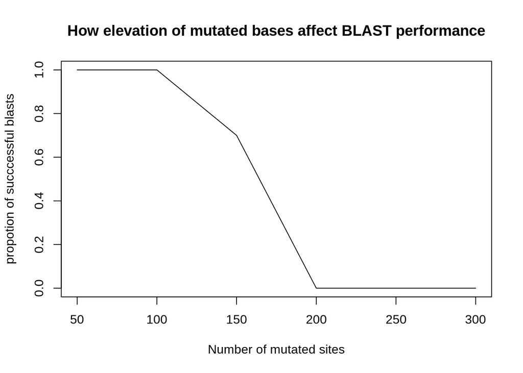

```r
plot(NMUTS,mutation_list,xlab="Number of mutated sites",ylab="propotion of succcessful blasts",main="How elevation of mutated bases affect BLAST performance",type="l")
```